# CRISPR screening - R practice

Olivier Harismendy

December 4th 2017

In this notebook, we will introdcue a few R packages that can be handy to manipulate, summarize and plot the data coming from the [PinAPL-py](http://pinapl-py.ucsd.edu) pipeline. Importantly, the methodologies presented here can be applied and expanded to any reasonnably sized dataset.

The packages used are loaded using the following set of commands. This assumes the packages have been installed using the install.package command (commented below) or the Rstudio Tools>Install Packages menu.

```r
#comment out the line below if you need to install the packages
#install.packages(c("dplyr","tidyr","reshape2","ineq","ggplot2","pheatmap","matrixStats"))

library(dplyr) # data wrangling and dataframe manipulation
library(tidyr) # data wrangling and dataframe manipulation
library(reshape2) # conversion between long and wide dataframe formats
library(ineq) # calculating gini coefficient (and others)
library(ggplot2) # versatile plotting package
library(pheatmap) # clustering and plotting pretty heatmaps
library(matrixStats) # to use the rowSd function
```

In order to best benefit from this practise and use case, one needs to be familiar with R data structure and manipulation, mostly differentating vector, matrix and dataframes. A primer on the different data types (numeric, integer, character, etc) is also useful.S Some general resources are mentioned towards the end of this tutorial.

The data used in this workshop corresponds to a GECKO screen in a cancer cell line, looking for enrichment of shRNA in cells treated with a genotoxic drug for 1h. 4 libraries from each Baseline (T0), Treated (T3_T) and Untreated (T3_U) were sequenced. In the first part we will study the sgRNA coverage count files, in a second section their significance.

# 1 Data Import and Formatting

The pipeline places the count data from each library in different folders. While there is a way to have R crawl through mulitple folders and import the data, we will assume here, for convenience, that the counts files have been placed in the same “counts” folder and renamed after the library ID. We will import the counts before normalization.

First we write a function that takes the file name (and path), import the content into a dataframe, names the columns, and add a column containing the name of the file.

```r
importCounts<-function(x){
  f<-read.delim(x,header=FALSE)
  colnames(f)<-c("sgRNA","gene", "value")
  f$Library<-x
  return(f)
}
```

Now we apply this function to a list of files in the folder.

```r
files <- list.files(path="./counts",pattern=".tsv",full.names = TRUE)
CountSg<-sapply(files,importCounts,simplify=FALSE)
```

We get a list of dataframes, which we collapse into one giant dataframe to which we remove the rownames, since they are not relevant.

```r
CountSg<-do.call(rbind,CountSg)
rownames(CountSg)<-NULL
```

We can now edit the dataframe and separate the library fields into subfields using the function tidyr::separate function

```r
CountSg<-separate(CountSg, Library, sep="[./]",into=c("pre1","pre2","folder","Library","ext1","ext2"),remove=TRUE)
```

and we keep only the column we care about using dplyr::select

```r
CountSg<-select(CountSg,sgRNA,gene,value,Library)
```

We have now a large dataframe containing all the counts data

# 2 Summary Statistics and Normalization

Here we will use mostly functions from the dplyr package. for example to determine the total number of counts in each library, N of sgRNA, N of covered sgRNA, Fraction of covered sgRNA.

```r
totalCounts<-CountSg %>% group_by(Library) %>% summarize(Total=sum(value),Ntotal=length(value),Ncovered=length(value[value>0]),FracCovered=length(value[value>0])/length(value))

totalCounts
```

```
## # A tibble: 12 x 5
##     Library    Total Ntotal Ncovered FracCovered
##       <chr>    <int>  <int>    <int>       <dbl>
##  1 I1R1T0_1 15679914 123411   116274   0.9421689
##  2 I1R1T3_T  7552567 123411   112430   0.9110209
##  3 I1R1T3_U 18449501 123411   115870   0.9388952
##  4 I1R2T0_1 14116155 123411   116283   0.9422418
##  5 I1R2T3_T  7253390 123411   107114   0.8679453
##  6 I1R2T3_U 15109877 123411   115817   0.9384658
##  7 I2R1T0_1 17376475 123411   116275   0.9421770
##  8 I2R1T3_T 16900882 123411   114355   0.9266192
##  9 I2R1T3_U 15423642 123411   115846   0.9387008
## 10 I2R2T0_1 15129315 123411   115891   0.9390654
## 11 I2R2T3_T 16019125 123411   112771   0.9137840
## 12 I2R2T3_U 17544022 123411   115825   0.9385306
```

We can therefore normalized the counts to the total number of counts in each library and multiply by 1E6 to get an RPM (read per million) unit. For this we can use the function dplyr::mutate, which can assign the results of an operation to a new column. But before we specify the grouping variable.

```r
CountSg<-CountSg %>% group_by(Library) %>% mutate(RPM=value*1E6/sum(value))
```

We can now verify that all the libraries have the same sum of RPM and can be compared

```r
CountSg %>% group_by(Library) %>% summarize(Total=sum(RPM))
```

```
## # A tibble: 12 x 2
##     Library Total
##       <chr> <dbl>
##  1 I1R1T0_1 1e+06
##  2 I1R1T3_T 1e+06
##  3 I1R1T3_U 1e+06
##  4 I1R2T0_1 1e+06
##  5 I1R2T3_T 1e+06
##  6 I1R2T3_U 1e+06
##  7 I2R1T0_1 1e+06
##  8 I2R1T3_T 1e+06
##  9 I2R1T3_U 1e+06
## 10 I2R2T0_1 1e+06
## 11 I2R2T3_T 1e+06
## 12 I2R2T3_U 1e+06
```

# 3 plotting cumulative distribution of counts

Let’s now look at the distribution of RPM in each library. For this, we can use the ggplot2 package to plot the cumulative distribution function. Which is similar to the Lorenz plot generated by PinAPL-Py. let’s start with one library, extracting the corresponding data using the dplyr::filter command

```r
C1<-filter(CountSg,Library=="I1R1T0_1")
```

A typical ggplot command starts with the `ggplot` fucntion, which specifies the dataframe and the variable to use in the “aesthetic” (x, y, colors, sizes, etc, etc). This function is then modified by adding the type of plot desired, here stat_ecdf(). The RPM values are following an exponential distribution (lots of low covered sgRNA, few highly covered), we will therefore plot their log10(RPM) to dampen the difference and transform into a normal distribution. In order to also represent the sgRNA that are not covered in the library (RPM=0), we will add a small number to all RPM. Finally, we specific the size of the plot (in inches) in the header.

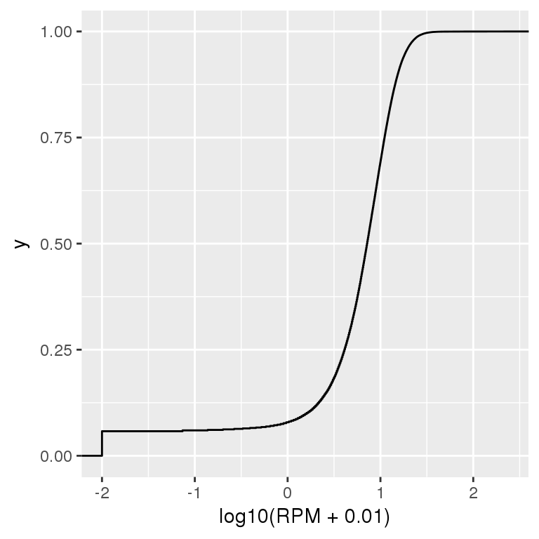

```r
ggplot(C1,aes(log10(RPM+0.01)))+stat_ecdf()
```

We can now change a bit the labels and the size of the font to make it prettier.

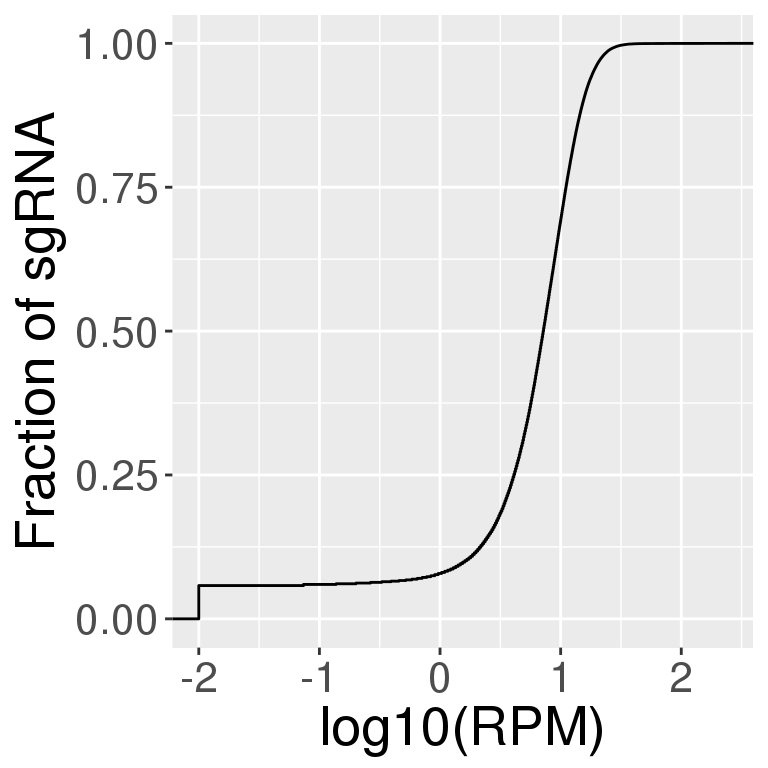

```r
ggplot(C1,aes(log10(RPM+0.01)))+stat_ecdf()+
  ylab("Fraction of sgRNA")+
  xlab("log10(RPM)")+
  theme(text=element_text(size=20))
```

and now we can plot all libraries on the same plot, by starting from the full datafrane and adding a color variable to the aesthetic, (and adjusting panel width to make room for the legend).

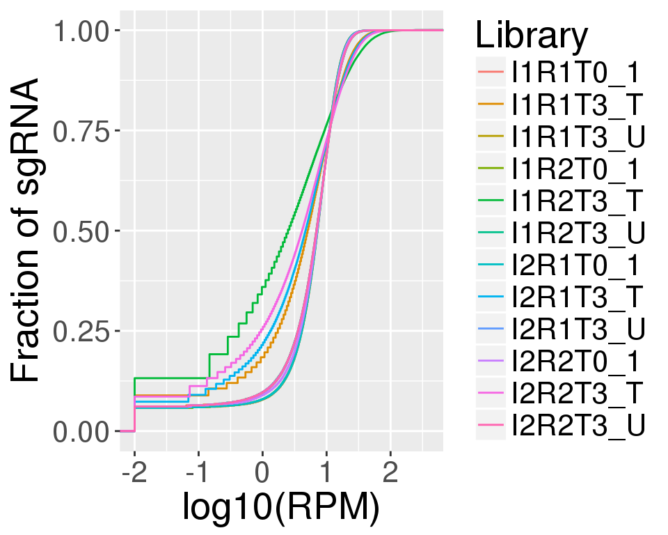

```r
ggplot(CountSg,aes(log10(RPM+0.01),col=Library))+stat_ecdf()+
  ylab("Fraction of sgRNA")+
  xlab("log10(RPM)")+
  theme(text=element_text(size=20))
```

Now, this is too many libraries to visualize on one plot, we should be able to separate them by timepoint and condition. We need to add another field to the dataframe. For this we will use the function `dplyr::mutate` seen before and perfrom a logical test based on the name of the library using `grepl`. `grepl` returns TRUE if the queried string is present in the tested string, FALSE otherwise. The function `ifelse` will assign the type to the type variable, as a result of this test.

```r
CountSg<-mutate(CountSg,type=ifelse(grepl("T0",Library),"Baseline","T3"))
CountSg<-mutate(CountSg,type=ifelse(grepl("T3_T",Library),"treated_T3",type))
CountSg<-mutate(CountSg,type=ifelse(grepl("T3_U",Library),"untreated_T3",type))
```

we can verify the new field, by listing the unique columns

```r
CountSg %>% select(Library,type) %>% unique()
```

```
## # A tibble: 12 x 2
## # Groups:   Library [12]
##     Library         type
##       <chr>        <chr>
##  1 I1R1T0_1     Baseline
##  2 I1R1T3_T   treated_T3
##  3 I1R1T3_U untreated_T3
##  4 I1R2T0_1     Baseline
##  5 I1R2T3_T   treated_T3
##  6 I1R2T3_U untreated_T3
##  7 I2R1T0_1     Baseline
##  8 I2R1T3_T   treated_T3
##  9 I2R1T3_U untreated_T3
## 10 I2R2T0_1     Baseline
## 11 I2R2T3_T   treated_T3
## 12 I2R2T3_U untreated_T3
```

and we can now use the function `facet_wrap` in ggplot to separate each type on a separate panel, increasing the width (resp. height) to make room if we display them in a row (resp. column)

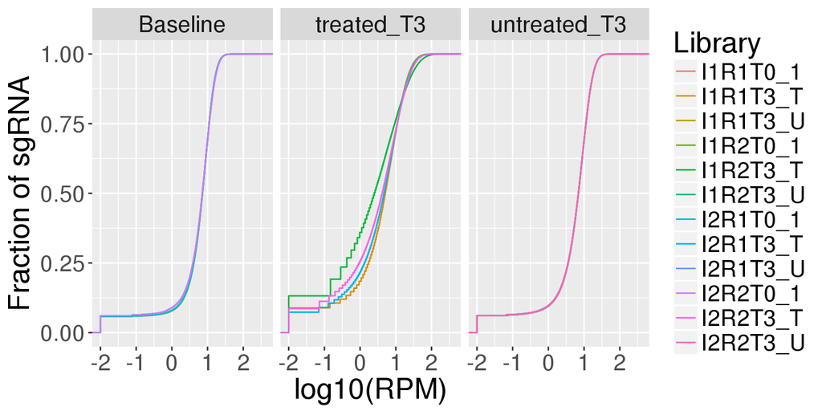

```r
ggplot(CountSg,aes(log10(RPM+0.01),col=Library))+stat_ecdf()+
  ylab("Fraction of sgRNA")+
  xlab("log10(RPM)")+
  theme(text=element_text(size=20))+
  facet_wrap(~type,ncol=3)
```

We can clearly see that some selection happened in the treated sample. Let’s calculte the gini coefficient for each library. This is provided by the function `ineq::ineq`

```r
gini<-CountSg %>% group_by(Library,type) %>% summarize(gini=ineq(RPM,type="Gini"))
gini
```

```
## # A tibble: 12 x 3
## # Groups:   Library [?]
##     Library         type      gini
##       <chr>        <chr>     <dbl>
##  1 I1R1T0_1     Baseline 0.3810707
##  2 I1R1T3_T   treated_T3 0.5591282
##  3 I1R1T3_U untreated_T3 0.4152534
##  4 I1R2T0_1     Baseline 0.3816828
##  5 I1R2T3_T   treated_T3 0.7085191
##  6 I1R2T3_U untreated_T3 0.4162315
##  7 I2R1T0_1     Baseline 0.3818141
##  8 I2R1T3_T   treated_T3 0.5865197
##  9 I2R1T3_U untreated_T3 0.4151149
## 10 I2R2T0_1     Baseline 0.3964067
## 11 I2R2T3_T   treated_T3 0.6185781
## 12 I2R2T3_U untreated_T3 0.4157668
```

Let’s plot the corresponding bar graph using the geom_bar function. Beause the value to plot is directly given by the gini field and that no math or calculations are needed, we need to specify `stat="identity"`

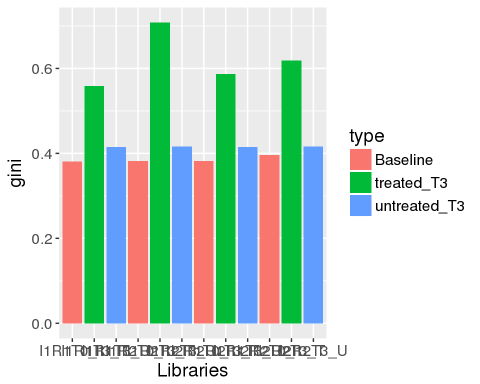

```r
ggplot(gini,aes(Library,gini,fill=type))+geom_bar(stat="identity")+
 ylab("gini")+
  xlab("Libraries")+
  theme(text=element_text(size=14))
```

Now this is not pretty, we can rotate the x axis labels in the `theme` variable. But before we need to change the levels of the Name and type variable so that they are not plotted in alphabetical order, but in the order we want.

```r
gini$Library<-factor(gini$Library,levels=c("I1R1T0_1","I1R2T0_1","I2R1T0_1","I2R2T0_1","I1R1T3_U","I1R2T3_U","I2R1T3_U","I2R2T3_U","I1R1T3_T","I1R2T3_T","I2R1T3_T","I2R2T3_T"))
```

Now we can replot, rotating the x axiss

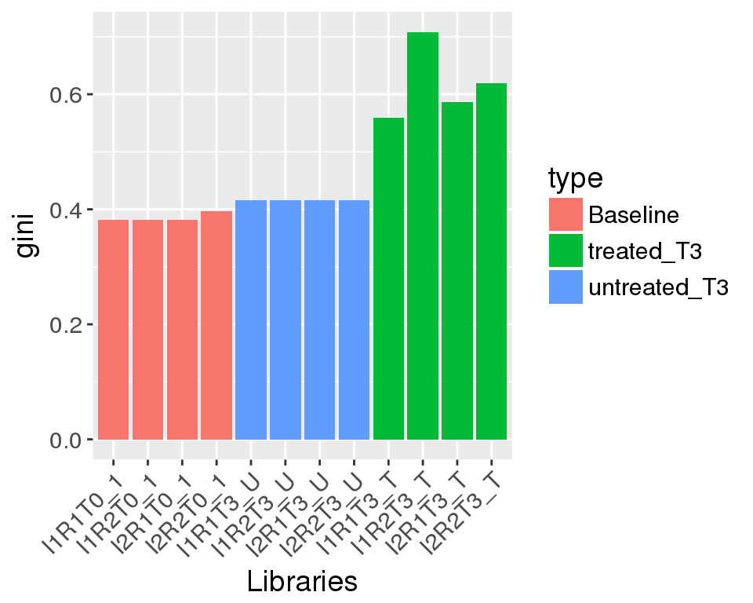

```r
ggplot(gini,aes(Library,gini,fill=type))+geom_bar(stat="identity")+
 ylab("gini")+
  xlab("Libraries")+
  theme(text=element_text(size=14),axis.text.x=element_text(angle=45,hjust=1))
```

# 4 Multidimentional plotting

## 4.1 Principal component

Selection has happened on all treated samples, but it is not clear whether the same sgRNAs are being selected. We can investigate the similarity in RPM profiles by calculating the first two principal components. For this, we first need to generate a matrix of sgRNA x Library using the function `reshape2:dcast`

```r
CountSgMat<-dcast(data=CountSg,sgRNA~Library,value.var="RPM")
head(CountSgMat)
```

```
##          sgRNA  I1R1T0_1  I1R1T3_T  I1R1T3_U I1R2T0_1 I1R2T3_T  I1R2T3_U
## 1 HGLibA_00001 11.607207 19.728392 15.555976 11.40537 7.996261 12.839284
## 2 HGLibA_00002  7.206672 18.271933 12.737472 10.83865 2.067999 10.125827
## 3 HGLibA_00003 13.456706 18.271933 17.615653 13.95564 1.654399 16.148378
## 4 HGLibA_00004  2.104603 17.080285  6.179029  3.47120 6.203996  3.573821
## 5 HGLibA_00005 16.262844  4.898997 12.629068 13.88480 5.652529 18.663289
## 6 HGLibA_00006 12.244965  4.236970  8.238705 11.40537 0.965066  6.618188
##    I2R1T0_1  I2R1T3_T  I2R1T3_U  I2R2T0_1   I2R2T3_T  I2R2T3_U
## 1 11.164520 16.744688 14.198981 10.509398 13.6711587 14.021870
## 2  9.610695  4.555975 12.059409  8.129912  1.0612315  7.979926
## 3 10.416382  6.863547 13.615461 11.699142  3.8079483 14.192869
## 4  3.855788  0.236674  3.241776  3.635327  1.4357838  4.502958
## 5 14.847660  9.348625 14.912172 14.805693  3.8079483 11.228896
## 6  9.207851 13.431252 13.680297 11.104270  0.4369777 14.990861
```

We can now convert this dataframe into a matrix, by assigning sgRNA field to the row names.

```r
rownames(CountSgMat)<-CountSgMat$sgRNA
CountSgMat<-select(CountSgMat,-sgRNA)
CountSgMat<-as.matrix(CountSgMat)
```

now I can calculate the principal components:

```r
pca<-prcomp(CountSgMat)
```

This is a list of two matrices, one for the standard deviation of each PC (`pca$sdev`) and one with the values of each PC (`pca$rotation`).

In order to use ggplot to plot the PC, I need to convert into a dataframe and add the name of each library as a new field to the pca

```r
pca<-as.data.frame(pca$rotation)
pca<-mutate(pca,Library=rownames(pca))
```

We can now plot using ggplot

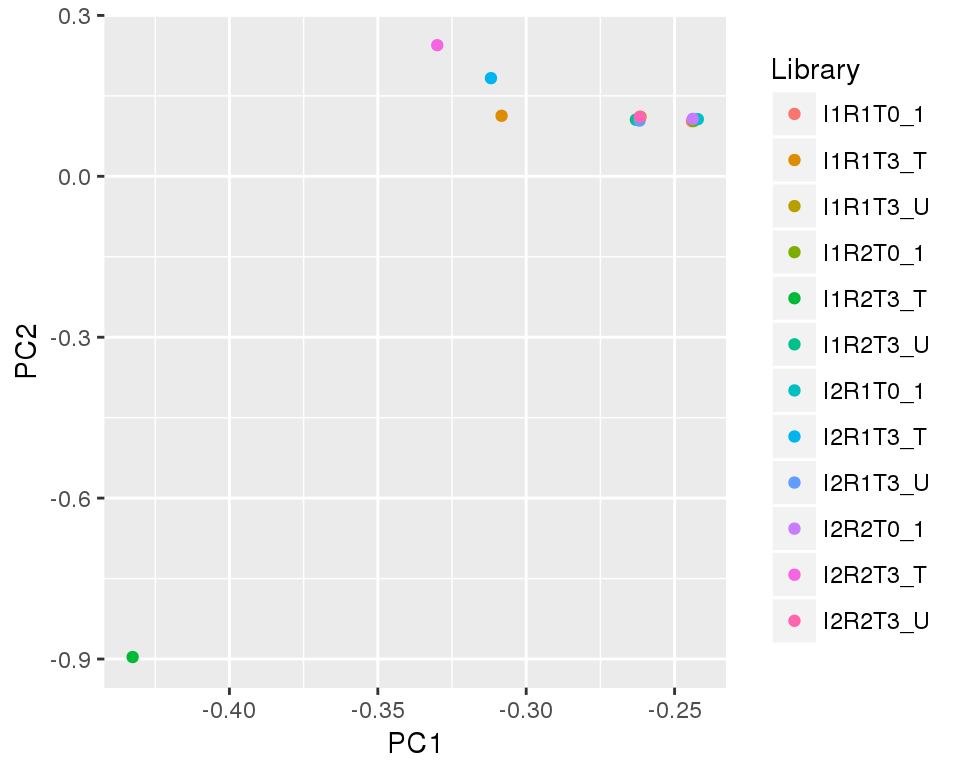

```r
ggplot(pca,aes(PC1,PC2,col=Library))+geom_point()
```

Now let’s make it prettier

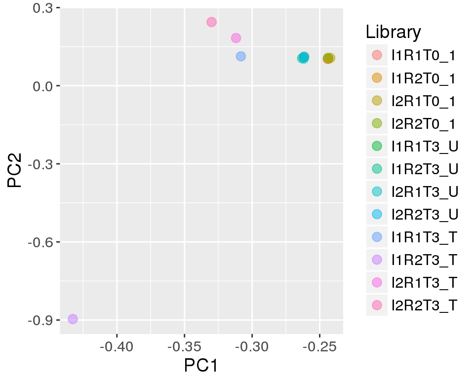

```r
pca$Library<-factor(pca$Library,levels=c("I1R1T0_1","I1R2T0_1","I2R1T0_1","I2R2T0_1","I1R1T3_U","I1R2T3_U","I2R1T3_U","I2R2T3_U","I1R1T3_T","I1R2T3_T","I2R1T3_T","I2R2T3_T"))


ggplot(pca,aes(PC1,PC2,col=Library))+geom_point(size=3, alpha=0.5)+
  theme(text=element_text(size=14))
```

We clearly see that all Baseline are similar, all untreated are similar, but each treated is very different, with a very strong outlier. Can I use custom colors and add some labels?

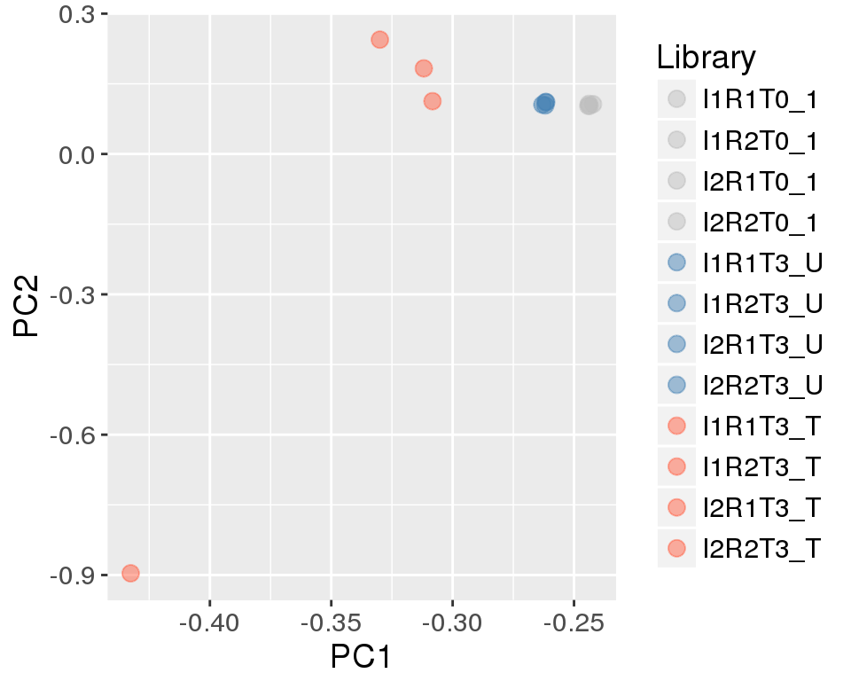

```r
ggplot(pca,aes(PC1,PC2,col=Library))+geom_point(size=3, alpha=0.5)+
  theme(text=element_text(size=14))+
  scale_color_manual(values=c(rep("grey",4),rep("steelblue",4),rep("tomato",4)))
```

## 4.2 clustering and heatmap

We can use the same matrix to cluster the samples and plot a heatmap of the RPM. Instead of using all sgRNAs for clustering, we will only use the top 500 most variable ones, which should capture most of the variance.

```r
CountSgMat<-dcast(data=CountSg,sgRNA~Library,value.var="RPM")
rownames(CountSgMat)<-CountSgMat$sgRNA
CountSgMat<-select(CountSgMat,-sgRNA)
CountSgMat$sd<-rowSds(as.matrix(CountSgMat))

CountSgMat500<-top_n(CountSgMat,500,sd)
CountSgMat500<-select(CountSgMat500,-sd)
CountSgMat500<-as.matrix(CountSgMat500)
```

Now I can use pheatmap function to do both clustering and plotting

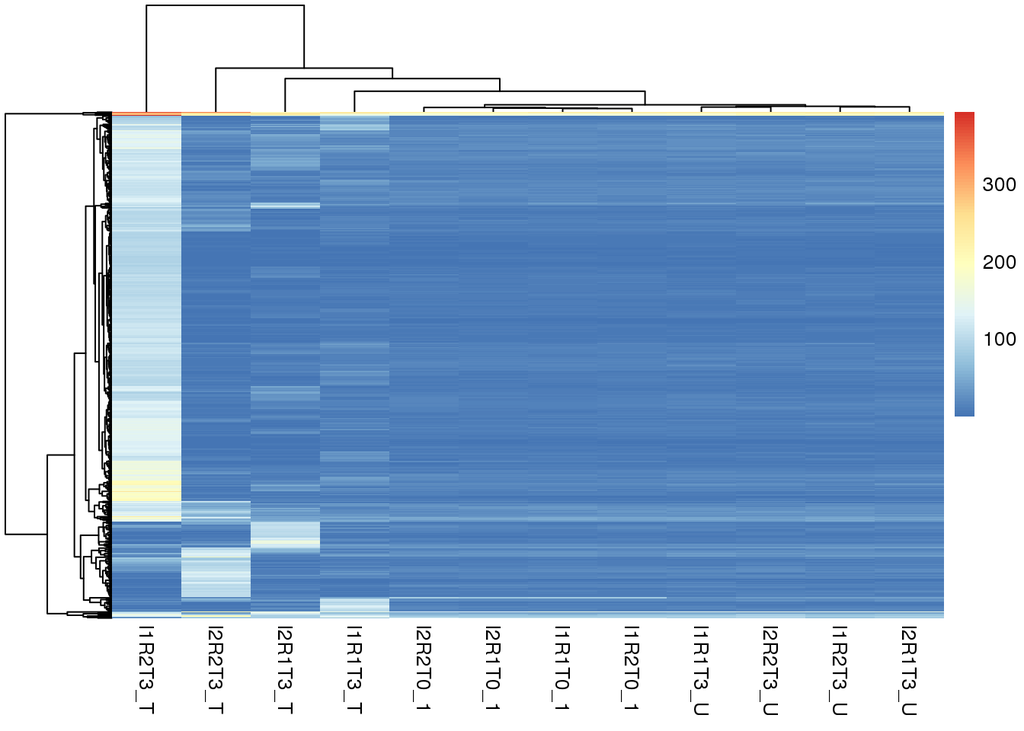

```r
pheatmap(CountSgMat500)
```

The color directly reflects the RPM level. In order to highlight the differences between samples, we can rescale each sgRNA RPM to a normal distribution, using the ‘scale’ argument. In that case the color scale represent the RPM on a z-scale. In addition, the dendrogam of the sgRNA is not informative, so we can remove it.

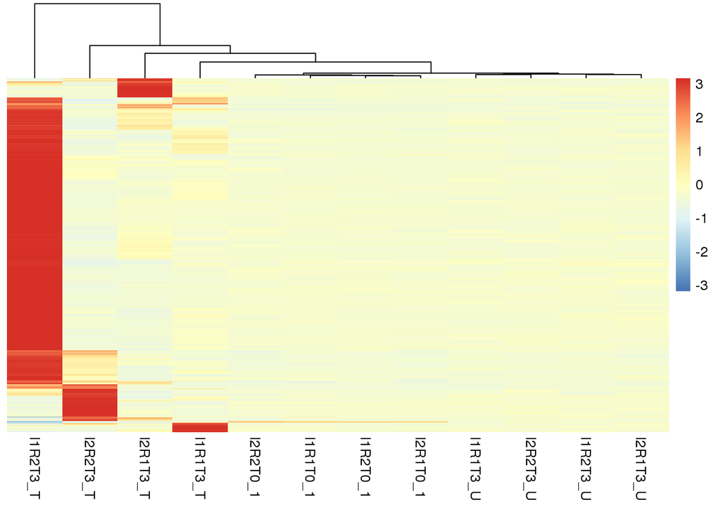

```r
pheatmap(CountSgMat500, scale="row", treeheight_row = 0)
```

To make it even prettier, we can add a sample annotation row, for this we need to prepare an annotation dataframe which rownames match the column names of the heatmap.

```r
annotation<-data.frame(Library=colnames(CountSgMat500))
```

Similar we what we have done for the cumulative distribution function, we can add the library type, we can also add technical and biological replicate number.

```r
annotation<-mutate(annotation,type=ifelse(grepl("T0",Library),"Baseline","T3"))
annotation<-mutate(annotation,type=ifelse(grepl("T3_T",Library),"treated_T3",type))
annotation<-mutate(annotation,type=ifelse(grepl("T3_U",Library),"untreated_T3",type))

annotation<-mutate(annotation,replicate=ifelse(grepl("R1",Library),"R1","R2"))
annotation<-mutate(annotation,infection=ifelse(grepl("I1",Library),"I1","I2"))
```

Then we can add a row name and remove the Library column

```r
rownames(annotation)<-annotation$Library
annotation<-select(annotation,-Library)
```

and add annotation color to the heatmap

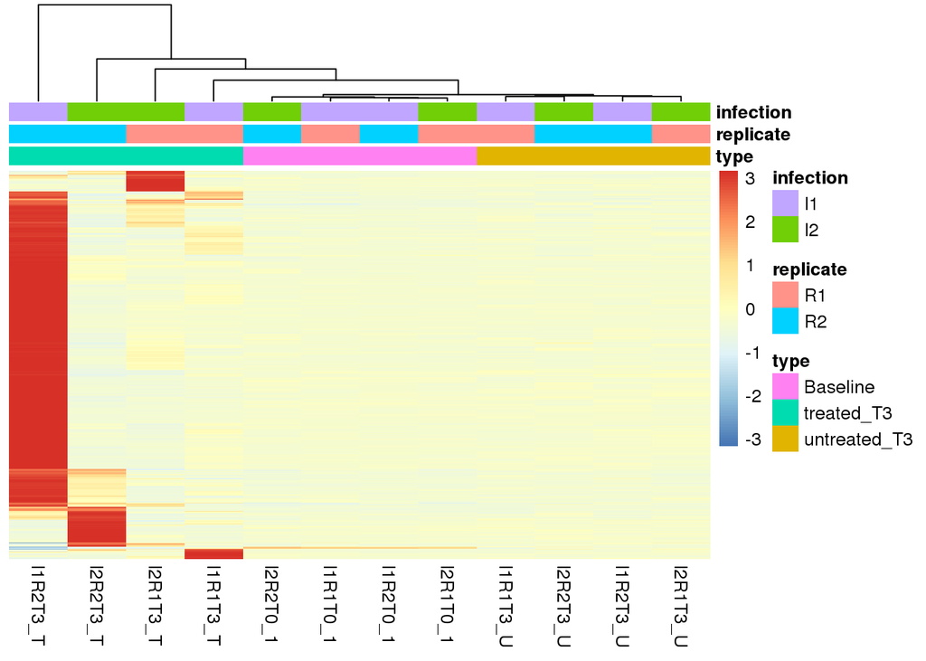

```r
pheatmap(CountSgMat500, scale="row", treeheight_row = 0, annotation_col = annotation)
```

# 5 Comparing Libraries

In this section, we will look at the results from PinAPL-Py statistical analysis, which gives us, for each treated library, the significance of enrichment, over the untreated libraries, using a negative binomial distribution model.

## 5.1 import the enrichment data

We first import the corresponding data, assuming here again that all files are located in the same ‘enrichment’ directory. We import them and group them into the same ‘enrichSg’ dataframe.

```r
importEnr<-function(x){
  f<-read.delim(x,header=TRUE,col.names=c("sgRNA","gene","RPM","control_mean","control_sd","FoldChange","pval","adj_pval","significant")) # edit header on the fly
  f$Library<-x
  return(f)
}

files <- list.files(path="./enrichment",pattern=".tsv",full.names = TRUE)
enrichSg<-sapply(files,importEnr,simplify=FALSE)
enrichSg<-do.call(rbind,enrichSg)
rownames(enrichSg)<-NULL
```

We can now reformat the filename into a proper library name and select the columns that we care about

```r
enrichSg<-separate(enrichSg, Library, sep="[./_]",into=c("pre1","pre2","folder","Library","ext1"),remove=TRUE)
enrichSg<-select(enrichSg,sgRNA,gene,RPM,control_mean,control_sd,FoldChange,pval,adj_pval,significant,Library)
```

## 5.2 basic statistics

first let’s remove the control non targeting RNA and the sgRNA tagertign miRNA.

```r
enrichSg %>%
  filter(!grepl("[Cc]ontrol",enrichSg$gene) & !grepl("hsa-",enrichSg$gene)) %>%
  group_by(Library) %>%
  summarize(Ntotal=length(sgRNA), Nsig=length(sgRNA[significant=="True"]))
```

```
## # A tibble: 4 x 3
##   Library Ntotal  Nsig
##     <chr>  <int> <int>
## 1  I1R1T3 114123  5922
## 2  I1R2T3 114123 11161
## 3  I2R1T3 114123  7449
## 4  I2R2T3 114123  9110
```

calculate the number of sgRNAs that are significant for each gene

```r
enrichSgSigGenes<-enrichSg %>%
  filter(!grepl("[Cc]ontrol",enrichSg$gene) & !grepl("hsa-",enrichSg$gene)) %>%
  filter(significant=="True") %>%
  group_by(Library,gene) %>%
  summarize(NSig=length(sgRNA))

enrichSgSigGenes
```

```
## # A tibble: 27,561 x 3
## # Groups:   Library [?]
##    Library    gene  NSig
##      <chr>  <fctr> <int>
##  1  I1R1T3    A1CF     1
##  2  I1R1T3  A4GALT     1
##  3  I1R1T3 AADACL2     2
##  4  I1R1T3 AADACL4     2
##  5  I1R1T3   AAGAB     1
##  6  I1R1T3    AAK1     1
##  7  I1R1T3    AAMP     1
##  8  I1R1T3    AAR2     1
##  9  I1R1T3    AARD     1
## 10  I1R1T3  ABCA10     2
## # ... with 27,551 more rows
```

How many significant genes in each significance category?

```r
Ngenes<-enrichSgSigGenes %>% group_by(Library,NSig) %>% summarize(N=length(gene))
Ngenes
```

```
## # A tibble: 18 x 3
## # Groups:   Library [?]
##    Library  NSig     N
##      <chr> <int> <int>
##  1  I1R1T3     1  4478
##  2  I1R1T3     2   641
##  3  I1R1T3     3    50
##  4  I1R1T3     4     3
##  5  I1R2T3     1  6586
##  6  I1R2T3     2  1800
##  7  I1R2T3     3   294
##  8  I1R2T3     4    22
##  9  I1R2T3     5     1
## 10  I2R1T3     1  5201
## 11  I2R1T3     2   941
## 12  I2R1T3     3   115
## 13  I2R1T3     4     4
## 14  I2R1T3     5     1
## 15  I2R2T3     1  5924
## 16  I2R2T3     2  1321
## 17  I2R2T3     3   172
## 18  I2R2T3     4     7
```

which we can cast as a nice table:

```r
dcast(Ngenes,Library~NSig,value.var="N")
```

```
##   Library    1    2   3  4  5
## 1  I1R1T3 4478  641  50  3 NA
## 2  I1R2T3 6586 1800 294 22  1
## 3  I2R1T3 5201  941 115  4  1
## 4  I2R2T3 5924 1321 172  7 NA
```

Finally, we can determine which genes are enriched in at least 2 replicates, through any sgRNAs

```r
enrichSg %>%
  filter(!grepl("[Cc]ontrol",enrichSg$gene) & !grepl("hsa-",enrichSg$gene)) %>%
  filter(significant=="True") %>%
  select(Library,gene) %>%
  unique() %>%
  group_by(gene) %>%
  summarize(NLib=length(Library)) %>%
  group_by(NLib) %>%
  summarize(Ngene=length(gene))
```

```
## # A tibble: 4 x 2
##    NLib Ngene
##   <int> <int>
## 1     1  6845
## 2     2  6061
## 3     3  2426
## 4     4   329
```

I can now export the list of genes replicated in 4 libraries using the ‘write.table’ function.

```r
tmp<-enrichSg %>%
  filter(!grepl("[Cc]ontrol",enrichSg$gene) & !grepl("hsa-",enrichSg$gene)) %>%
  filter(significant=="True") %>%
  select(Library,gene) %>%
  unique() %>%
  group_by(gene) %>%
  summarize(NLib=length(Library)) %>%
  filter(NLib==4)


write.table(tmp,"GeneRep4.txt",sep="\t",quote = FALSE,row.names = FALSE)
```

## 5.3 Plotting enrichment

For each sgRNA in each library, we will plot the RPM as a function of the control mean.

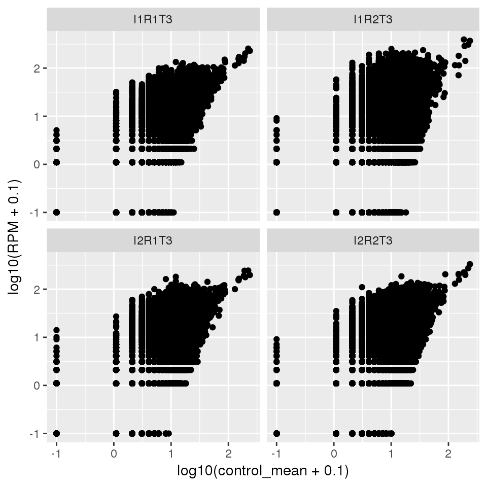

```r
ggplot(enrichSg,aes(log10(control_mean+0.1),log10(RPM+0.1)))+geom_point()+facet_wrap(~Library)
```

coloring the significant ones in red, and the rest in grey

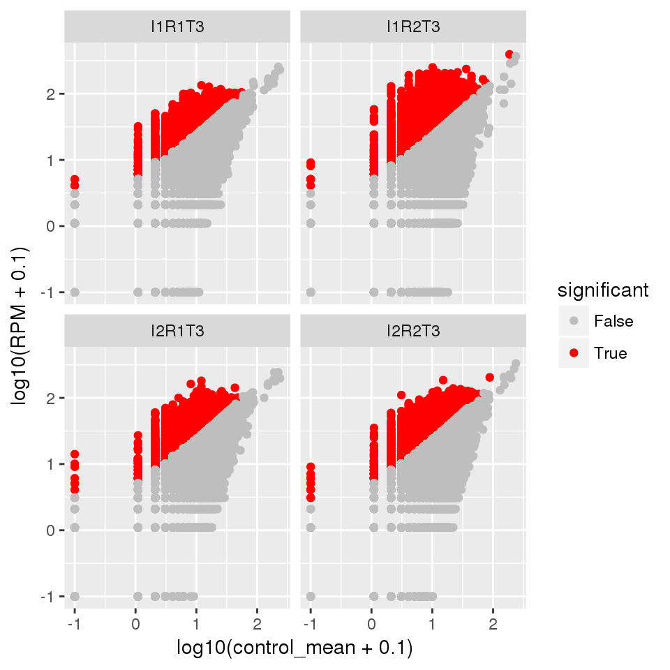

```r
ggplot(enrichSg,aes(log10(control_mean+0.1),log10(RPM+0.1),col=significant))+geom_point()+
  facet_wrap(~Library)+
  scale_color_manual(values=c("grey","red"))
```

We can also generate a bar chart of the number of enriched sgRNAs.

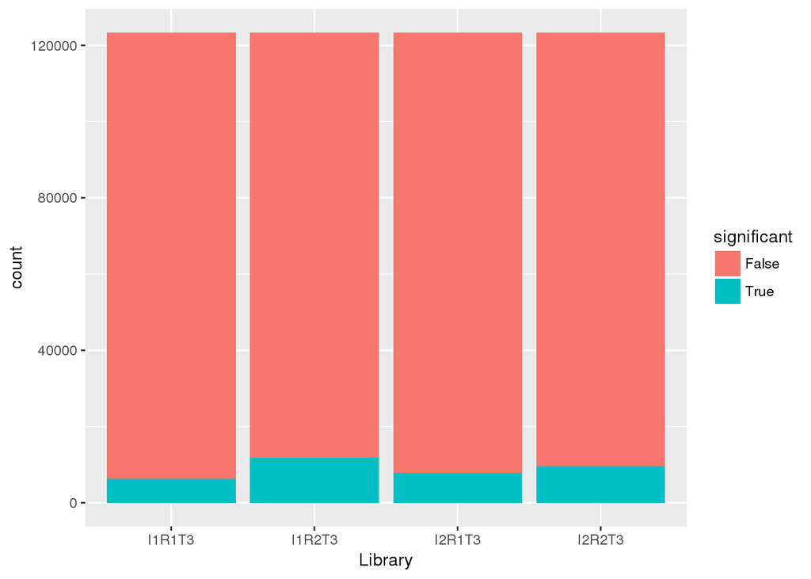

```r
ggplot(enrichSg,aes(Library,fill=significant))+geom_bar()
```

# 6 Other resources

- I enjoy the blog from Steven Turner “Getting Genetics Done” http://www.gettinggeneticsdone.com, which provides great example of R/bioconductor applied to genomics.
- For a more classic training in R and bioconductor, refer to the excellent tutorial from Thomas Girke http://manuals.bioinformatics.ucr.edu/home/R_BioCondManual
- Finally, there are a number of cheatsheets, that you may want to keep close to you.
- dplyr & tidyr https://www.rstudio.com/wp-content/uploads/2015/02/data-wrangling-cheatsheet.pdf
- ggplot https://www.rstudio.com/wp-content/uploads/2015/03/ggplot2-cheatsheet.pdf
- colors https://www.nceas.ucsb.edu/~frazier/RSpatialGuides/colorPaletteCheatsheet.pdf